# Поиск потенциально популярного продукта в сегменте компьютерных игр для запуска рекламной кампании в интернет-магазине "Стримчик"

Интернет-магазине «Стримчик» продаёт по всему миру компьютерные игры. Руководство магазина планирует рекламную кампанию на предстоящий год, в рамках имеющейся стратегии развития бизнеса.

**Цель исследования:** выявить показатели и закономерности, определяющие успешность игр, для планирования рекламной кампании.

**Ход исследования:**

- Найти открытые источники с историческими данными о продажах игр.
- Выполнить предобработку данных (замените названия столбцов при необходимости, преобразовать данные в нужные типы, обработать пропуски при необходимости)
- Провести исследовательский анализ данных (оценить разброс значений по показателям, выявить закономерности, корреляции между показателями. Применительно к конкретной цели оценить продажи игр в зависимости от платформы, жанра, рейтинга покупателей и др.)
- Выдвинуть гипотезы о большей успешности игры (больших продажах) в зависимости от выявленных факторов, проверить их статистически.
- Предоставить аргументированные выводы, полученные в ходе исследования (указать маркетолагам на показатели, которые определяют потенциальную успешность игр).

## Открываем данные и изучаем общую информацию

```python
# Импортируем необходимые для работы библиотеки
import pandas as pd
import numpy as np
from scipy import stats as st
import matplotlib.pyplot as plt
import seaborn as sns
from skimpy import clean_columns
import warnings

warnings.filterwarnings('ignore')
```

```python
# Загружаем файл и просмотрим общую информацию о датасете
try:
    df = pd.read_csv('/Users/amirk/Downloads/games.csv')
except:
    df = pd.read_csv('/datasets/games.csv')

df.head()
```

|  | Name | Platform | Year_of_Release | Genre | NA_sales | EU_sales | JP_sales | Other_sales | Critic_Score | User_Score | Rating |
| --- | --- | --- | --- | --- | --- | --- | --- | --- | --- | --- | --- |
| 0 | Wii Sports | Wii | 2006.0 | Sports | 41.36 | 28.96 | 3.77 | 8.45 | 76.0 | 8 | E |
| 1 | Super Mario Bros. | NES | 1985.0 | Platform | 29.08 | 3.58 | 6.81 | 0.77 | NaN | NaN | NaN |
| 2 | Mario Kart Wii | Wii | 2008.0 | Racing | 15.68 | 12.76 | 3.79 | 3.29 | 82.0 | 8.3 | E |
| 3 | Wii Sports Resort | Wii | 2009.0 | Sports | 15.61 | 10.93 | 3.28 | 2.95 | 80.0 | 8 | E |
| 4 | Pokemon Red/Pokemon Blue | GB | 1996.0 | Role-Playing | 11.27 | 8.89 | 10.22 | 1.00 | NaN | NaN | NaN |

```python
df.info()
```

```
<class 'pandas.core.frame.DataFrame'>
RangeIndex: 16715 entries, 0 to 16714
Data columns (total 11 columns):
 #   Column           Non-Null Count  Dtype
---  ------           --------------  -----
 0   Name             16713 non-null  object
 1   Platform         16715 non-null  object
 2   Year_of_Release  16446 non-null  float64
 3   Genre            16713 non-null  object
 4   NA_sales         16715 non-null  float64
 5   EU_sales         16715 non-null  float64
 6   JP_sales         16715 non-null  float64
 7   Other_sales      16715 non-null  float64
 8   Critic_Score     8137 non-null   float64
 9   User_Score       10014 non-null  object
 10  Rating           9949 non-null   object
dtypes: float64(6), object(5)
memory usage: 1.4+ MB
```

У нас достаточно большой датафрейм, что позволит нам сделать статистически значимые выводы. Большинство столбцов заполнено без пропусков, однако показатели связанные с рейтингами (`Critic_Score`,`User_Score`, `Rating`) имеют пропуски, что вероятно связано с годом выхода игр (на заре продаж компьютерных игр такие параметры не оценивались. Позже проверим данное предположение.)

## Предобработка данных

### Замена названий столбцов

Из полученных выше данных мы видим, что названия столбцов написаны не в общепринятом **`змеином_регистре`**. Исправим это!

```python
df = clean_columns(df)
df.head()
```

```
11 column names have been cleaned
```

|  | name | platform | year_of_release | genre | na_sales | eu_sales | jp_sales | other_sales | critic_score | user_score | rating |
| --- | --- | --- | --- | --- | --- | --- | --- | --- | --- | --- | --- |
| 0 | Wii Sports | Wii | 2006.0 | Sports | 41.36 | 28.96 | 3.77 | 8.45 | 76.0 | 8 | E |
| 1 | Super Mario Bros. | NES | 1985.0 | Platform | 29.08 | 3.58 | 6.81 | 0.77 | NaN | NaN | NaN |
| 2 | Mario Kart Wii | Wii | 2008.0 | Racing | 15.68 | 12.76 | 3.79 | 3.29 | 82.0 | 8.3 | E |
| 3 | Wii Sports Resort | Wii | 2009.0 | Sports | 15.61 | 10.93 | 3.28 | 2.95 | 80.0 | 8 | E |
| 4 | Pokemon Red/Pokemon Blue | GB | 1996.0 | Role-Playing | 11.27 | 8.89 | 10.22 | 1.00 | NaN | NaN | NaN |

Замены выполнена корректно!

### Преобразование типов данных

При первичном знакомстве с данными, было выявлено несоответсвие типов данных в некоторых столбцах:

- **year_of_release** - нужно заменить на тип `datetime`
- **user_score** - нужно заменить на тип `float64`

Выполним преобразование!

```python
df['year_of_release'] = pd.to_datetime(df['year_of_release'], format='%Y')

# преобразование типа данных в столбце user_csore приводит к ошибке
# посмотрим какие значения встречаются в данном столбце
df['user_score'].value_counts()
```

```
tbd    2424
7.8     324
8       290
8.2     282
8.3     254
       ...
1.1       2
1.9       2
9.6       2
0         1
9.7       1
Name: user_score, Length: 96, dtype: int64
```

```python
# Получено 2424 строковых значения 'tbd' - to be decided/determined
# эти значения эще не посчитаны, возвможно это данные за последний год. Проверим.
tbd_stat = df[df['user_score'] == 'tbd']['year_of_release'].value_counts().sort_index()
print(tbd_stat)
```

```
1997-01-01      1
1999-01-01      8
2000-01-01     43
2001-01-01     82
2002-01-01    192
2003-01-01     95
2004-01-01    107
2005-01-01    121
2006-01-01    124
2007-01-01    192
2008-01-01    326
2009-01-01    405
2010-01-01    331
2011-01-01    217
2012-01-01     24
2013-01-01     15
2014-01-01     21
2015-01-01     38
2016-01-01     34
Name: year_of_release, dtype: int64
```

Видно, что значение **tbd** встречается в разные годы. с 2012 по 2016 гг таких значений мало, статистика ведется более полноценно. За предыдущие годы данная статистика велась достаточно плохо. Возможно продажи данных игр достаточно низкие, их процент от общего количества продаж очень мал и мы сможем удалить данные значения из датасета. Проверим.

```python
tbd_stat = tbd_stat.reset_index().rename(columns={'index': 'year_of_release','year_of_release': 'tbd_per_year'})

#создадис список стран для использования
country_list = ['na_sales', 'eu_sales', 'jp_sales', 'other_sales']
for j in country_list:
    tbd_list = []
    for i in tbd_stat['year_of_release']:
        a = (df.loc[(df['user_score'] == 'tbd') & (df['year_of_release'] == i)][j].sum()) / (df[df['year_of_release'] == i][j].sum())
        tbd_list.append((a * 100).round(2))
    tbd_stat[j] = tbd_list
tbd_stat
```

|  | year_of_release | tbd_per_year | na_sales | eu_sales | jp_sales | other_sales |
| --- | --- | --- | --- | --- | --- | --- |
| 0 | 1997-01-01 | 1 | 0.03 | 0.04 | 0.00 | 0.00 |
| 1 | 1999-01-01 | 8 | 2.58 | 1.40 | 0.00 | 1.49 |
| 2 | 2000-01-01 | 43 | 7.74 | 9.76 | 0.75 | 9.81 |
| 3 | 2001-01-01 | 82 | 6.94 | 6.86 | 0.70 | 5.41 |
| 4 | 2002-01-01 | 192 | 7.85 | 6.48 | 0.60 | 4.11 |
| 5 | 2003-01-01 | 95 | 5.06 | 3.88 | 0.00 | 2.58 |
| 6 | 2004-01-01 | 107 | 6.71 | 5.57 | 1.10 | 1.71 |
| 7 | 2005-01-01 | 121 | 5.34 | 3.97 | 0.33 | 2.68 |
| 8 | 2006-01-01 | 124 | 3.88 | 2.02 | 1.89 | 2.04 |
| 9 | 2007-01-01 | 192 | 9.44 | 5.63 | 1.51 | 5.13 |
| 10 | 2008-01-01 | 326 | 13.46 | 8.45 | 0.91 | 9.76 |
| 11 | 2009-01-01 | 405 | 16.68 | 7.41 | 0.74 | 11.26 |
| 12 | 2010-01-01 | 331 | 16.48 | 8.37 | 1.41 | 10.11 |
| 13 | 2011-01-01 | 217 | 10.44 | 5.43 | 0.24 | 6.52 |
| 14 | 2012-01-01 | 24 | 0.55 | 0.90 | 0.46 | 0.55 |
| 15 | 2013-01-01 | 15 | 0.24 | 0.69 | 0.02 | 0.26 |
| 16 | 2014-01-01 | 21 | 1.04 | 1.15 | 0.38 | 0.76 |
| 17 | 2015-01-01 | 38 | 0.88 | 1.30 | 1.20 | 0.76 |
| 18 | 2016-01-01 | 34 | 1.54 | 1.66 | 0.16 | 1.10 |

```python
df.loc[df['user_score'] == 'tbd', 'user_score'] = np.NaN
df['user_score'] = df['user_score'].astype('float')
df.info()
```

```
<class 'pandas.core.frame.DataFrame'>
RangeIndex: 16715 entries, 0 to 16714
Data columns (total 11 columns):
 #   Column           Non-Null Count  Dtype
---  ------           --------------  -----
 0   name             16713 non-null  object
 1   platform         16715 non-null  object
 2   year_of_release  16446 non-null  datetime64[ns]
 3   genre            16713 non-null  object
 4   na_sales         16715 non-null  float64
 5   eu_sales         16715 non-null  float64
 6   jp_sales         16715 non-null  float64
 7   other_sales      16715 non-null  float64
 8   critic_score     8137 non-null   float64
 9   user_score       7590 non-null   float64
 10  rating           9949 non-null   object
dtypes: datetime64[ns](1), float64(6), object(4)
memory usage: 1.4+ MB
```

### Обработка пропусков

Вспомним, где были пропуски в датафрейме

```python
df.isna().sum()
```

```
name                  2
platform              0
year_of_release     269
genre                 2
na_sales              0
eu_sales              0
jp_sales              0
other_sales           0
critic_score       8578
user_score         9125
rating             6766
dtype: int64
```

Проверим более подробнее пропуски в каждом столбце, по возможности удалим.

```python
df[df['name'].isna() == True]
```

|  | name | platform | year_of_release | genre | na_sales | eu_sales | jp_sales | other_sales | critic_score | user_score | rating |
| --- | --- | --- | --- | --- | --- | --- | --- | --- | --- | --- | --- |
| 659 | NaN | GEN | 1993-01-01 | NaN | 1.78 | 0.53 | 0.00 | 0.08 | NaN | NaN | NaN |
| 14244 | NaN | GEN | 1993-01-01 | NaN | 0.00 | 0.00 | 0.03 | 0.00 | NaN | NaN | NaN |

Обе строчки с пропусками являются абсолютно неинформативными, нет названия игры, жанра и оценок. Смело удаляем данные строки.

```python
df = df.dropna(subset=['name'])
df.info()
df.isna().sum()
```

```
<class 'pandas.core.frame.DataFrame'>
Int64Index: 16713 entries, 0 to 16714
Data columns (total 11 columns):
 #   Column           Non-Null Count  Dtype
---  ------           --------------  -----
 0   name             16713 non-null  object
 1   platform         16713 non-null  object
 2   year_of_release  16444 non-null  datetime64[ns]
 3   genre            16713 non-null  object
 4   na_sales         16713 non-null  float64
 5   eu_sales         16713 non-null  float64
 6   jp_sales         16713 non-null  float64
 7   other_sales      16713 non-null  float64
 8   critic_score     8137 non-null   float64
 9   user_score       7590 non-null   float64
 10  rating           9949 non-null   object
dtypes: datetime64[ns](1), float64(6), object(4)
memory usage: 1.5+ MB
```

```
name                  0
platform              0
year_of_release     269
genre                 0
na_sales              0
eu_sales              0
jp_sales              0
other_sales           0
critic_score       8576
user_score         9123
rating             6764
dtype: int64
```

Удалив пропуски в именах, мы удалили и пропуски в жанре

```python
# Оценим пропуски в year_of_release
df[df['year_of_release'].isna() == True]
```

|  | name | platform | year_of_release | genre | na_sales | eu_sales | jp_sales | other_sales | critic_score | user_score | rating |
| --- | --- | --- | --- | --- | --- | --- | --- | --- | --- | --- | --- |
| 183 | Madden NFL 2004 | PS2 | NaT | Sports | 4.26 | 0.26 | 0.01 | 0.71 | 94.0 | 8.5 | E |
| 377 | FIFA Soccer 2004 | PS2 | NaT | Sports | 0.59 | 2.36 | 0.04 | 0.51 | 84.0 | 6.4 | E |
| 456 | LEGO Batman: The Videogame | Wii | NaT | Action | 1.80 | 0.97 | 0.00 | 0.29 | 74.0 | 7.9 | E10+ |
| 475 | wwe Smackdown vs. Raw 2006 | PS2 | NaT | Fighting | 1.57 | 1.02 | 0.00 | 0.41 | NaN | NaN | NaN |
| 609 | Space Invaders | 2600 | NaT | Shooter | 2.36 | 0.14 | 0.00 | 0.03 | NaN | NaN | NaN |
| ... | ... | ... | ... | ... | ... | ... | ... | ... | ... | ... | ... |
| 16373 | PDC World Championship Darts 2008 | PSP | NaT | Sports | 0.01 | 0.00 | 0.00 | 0.00 | 43.0 | NaN | E10+ |
| 16405 | Freaky Flyers | GC | NaT | Racing | 0.01 | 0.00 | 0.00 | 0.00 | 69.0 | 6.5 | T |
| 16448 | Inversion | PC | NaT | Shooter | 0.01 | 0.00 | 0.00 | 0.00 | 59.0 | 6.7 | M |
| 16458 | Hakuouki: Shinsengumi Kitan | PS3 | NaT | Adventure | 0.01 | 0.00 | 0.00 | 0.00 | NaN | NaN | NaN |
| 16522 | Virtua Quest | GC | NaT | Role-Playing | 0.01 | 0.00 | 0.00 | 0.00 | 55.0 | 5.5 | T |

269 rows × 11 columns

Видно, что у многих игр в названии стоит год выпуска, можем заполнить пропуски этими данными.

```python
drop_years_list = df[df['year_of_release'].isna() == True]['name'].unique()
for i in drop_years_list:
    if (str(i).split(sep=' ')[-1].isnumeric() == True) and (len(str(i).split(sep=' ')[-1]) == 4):
        df.loc[df['name'] == i, 'year_of_release'] = (str(i).split(sep=' ')[-1])

        df.loc[df['name'] == i, 'year_of_release'] = pd.to_datetime(df.loc[df['name'] == i, 'year_of_release'], format='%Y')
df.isna().sum()
```

```
name                  0
platform              0
year_of_release     254
genre                 0
na_sales              0
eu_sales              0
jp_sales              0
other_sales           0
critic_score       8576
user_score         9123
rating             6764
dtype: int64
```

Не сильно, но уменьшили количество пропусков.

```
1980-01-01      9
1981-01-01     46
1982-01-01     36
1983-01-01     17
1984-01-01     14
1985-01-01     13
1986-01-01     21
1987-01-01     16
1988-01-01     14
1989-01-01     17
1990-01-01     16
1991-01-01     41
1992-01-01     42
1993-01-01     60
1994-01-01    120
1995-01-01    219
1996-01-01    255
1997-01-01    272
1998-01-01    351
1999-01-01    299
2000-01-01    207
2001-01-01    154
2002-01-01    204
2003-01-01    190
2004-01-01    201
2005-01-01    284
2006-01-01    388
2007-01-01    506
2008-01-01    713
2009-01-01    775
2010-01-01    755
2011-01-01    636
2012-01-01    332
2013-01-01    271
2014-01-01    320
2015-01-01    381
2016-01-01    270
Name: year_of_release, dtype: int64
```

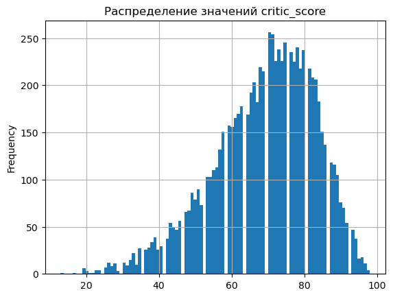

```python
# Оценим пропуски в critic_score
# Особо интересует распределение пропусков по годам

print(df[df['critic_score'].isna() == True]['year_of_release'].value_counts().sort_index())

# Заодно оценим распределение показателя
df['critic_score'].plot(kind='hist', bins=100, title='Распределение значений critic_score', grid=True)
plt.show()
```

Видим, что пропусков достаточно в каждом из годов. Заполнять пропуски медианным или средним значением в зависимости от года выхода, жанра, платформы, названия игры и тд. - нельзя! Потому что выход новой игры или новой версии абсолютно не означает схожие оценки с предыдущей версией. Новая версия игры может быть оценена намного выше или ниже медианного значения.  
Просто удалить пропуски мы не можем, потому что это около половины датасета, мы исказим результаты. Поэтому оставим пропуски!  
Также в данных нет выбросов и атипичных значений.

```
1980-01-01      9
1981-01-01     46
1982-01-01     36
1983-01-01     17
1984-01-01     14
1985-01-01     13
1986-01-01     21
1987-01-01     16
1988-01-01     14
1989-01-01     17
1990-01-01     16
1991-01-01     41
1992-01-01     42
1993-01-01     60
1994-01-01    120
1995-01-01    219
1996-01-01    255
1997-01-01    271
1998-01-01    348
1999-01-01    307
2000-01-01    243
2001-01-01    222
2002-01-01    367
2003-01-01    261
2004-01-01    273
2005-01-01    356
2006-01-01    456
2007-01-01    569
2008-01-01    768
2009-01-01    812
2010-01-01    788
2011-01-01    635
2012-01-01    314
2013-01-01    240
2014-01-01    252
2015-01-01    309
2016-01-01    240
Name: year_of_release, dtype: int64
```

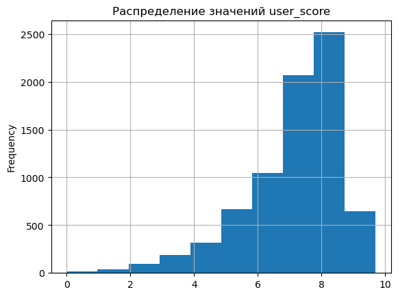

```python
# Так же оценим пропуски в user_score
print(df[df['user_score'].isna() == True]['year_of_release'].value_counts().sort_index())
df['user_score'].plot(kind='hist', bins=10, title='Распределение значений user_score', grid=True);
plt.show()
```

Аналогичная ситуация как и в `critic_score`. Пропуски оставляем, атипичных значений в данных нет!

```
1980-01-01      9
1981-01-01     46
1982-01-01     36
1983-01-01     17
1984-01-01     14
1985-01-01     13
1986-01-01     21
1987-01-01     16
1988-01-01     14
1989-01-01     17
1990-01-01     16
1991-01-01     41
1992-01-01     41
1993-01-01     60
1994-01-01    120
1995-01-01    219
1996-01-01    256
1997-01-01    270
1998-01-01    347
1999-01-01    296
2000-01-01    202
2001-01-01    142
2002-01-01    175
2003-01-01    162
2004-01-01    164
2005-01-01    233
2006-01-01    330
2007-01-01    377
2008-01-01    447
2009-01-01    415
2010-01-01    456
2011-01-01    434
2012-01-01    298
2013-01-01    228
2014-01-01    236
2015-01-01    291
2016-01-01    222
Name: year_of_release, dtype: int64
```

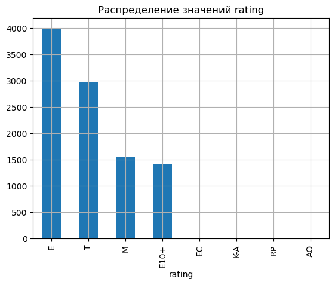

```python
# Ожидаем, что в rating будет аналогичная ситуация

print(df[df['rating'].isna() == True]['year_of_release'].value_counts().sort_index())
df.pivot_table(index='rating', values='name', aggfunc='count').sort_values(by='name', ascending=False).plot(kind='bar', title='Распределение значений rating', grid=True, legend=False);
plt.show()
```

Ожидания оправдались, аналогичная закономерность. Пропуски оставляем, атипичных значений в данных нет!

Пропуски в year_of_release могли возникнуть из-за ошибки в системе сбора информации, возможно при переносе данных их одной базы данных в общую.  
Пропуски в столбцах с оценками и рейтингом могли также возникнуть по причине ошибок в системе сбора информации, некоторые малопулярные игры могли быть просто не оценены пользователями и по рейтингу или авторы игр просто не отправляли разработанную игру на получение оценки и рейтинга.

### Посчет суммарных продаж во всех регионах

Создадим столбец `total_sales` и внесем в него сумму продаж по всем регионам.

```python
df['total_sales'] = df[country_list].sum(axis=1)
df.head()
```

|  | name | platform | year_of_release | genre | na_sales | eu_sales | jp_sales | other_sales | critic_score | user_score | rating | total_sales |
| --- | --- | --- | --- | --- | --- | --- | --- | --- | --- | --- | --- | --- |
| 0 | Wii Sports | Wii | 2006-01-01 | Sports | 41.36 | 28.96 | 3.77 | 8.45 | 76.0 | 8.0 | E | 82.54 |
| 1 | Super Mario Bros. | NES | 1985-01-01 | Platform | 29.08 | 3.58 | 6.81 | 0.77 | NaN | NaN | NaN | 40.24 |
| 2 | Mario Kart Wii | Wii | 2008-01-01 | Racing | 15.68 | 12.76 | 3.79 | 3.29 | 82.0 | 8.3 | E | 35.52 |
| 3 | Wii Sports Resort | Wii | 2009-01-01 | Sports | 15.61 | 10.93 | 3.28 | 2.95 | 80.0 | 8.0 | E | 32.77 |
| 4 | Pokemon Red/Pokemon Blue | GB | 1996-01-01 | Role-Playing | 11.27 | 8.89 | 10.22 | 1.00 | NaN | NaN | NaN | 31.38 |

**Промежуточные итоги**

- заменили названия столбцов на общепринятый формат
- заменили типы данных
- заполнили пропуски там, где это возможно. В столбце user_score заменили значения **tbd** на **NaN**, чтобы можно было вести работу с цифрами и не потерять около половины данных. Данное значение **tbd** вероятно возникло из-за ошибок системы сбора статистики. В столбцах с оценками пропуски оставили, так-так оценки игры среди пользователей предугадать сложно, в разных версиях игр могут быть 'взлеты' и 'падения'.
- посчитали общий обьем продаж по каждой позиции.

## Исследовательский анализ данных

Нам нужно выделить **актуальный период** в годах, данные за который мы могли бы использовать для прогнозирования потенциально успешного продукта в 2017гг. Это все связано с изменением тенденций в мире компьютерных игр.

### Оценим, сколько игр выспускалось в разные годы

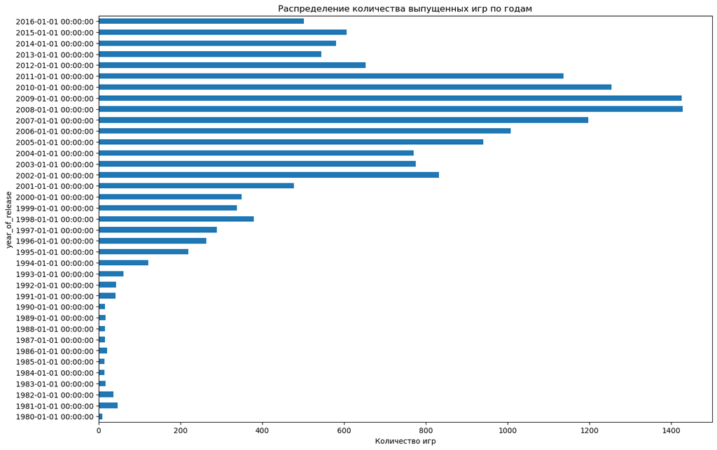

```python
df.groupby('year_of_release')['name'].count().plot(kind='barh', figsize=(15,10))
plt.xlabel('Количество игр')
plt.title('Распределение количества выпущенных игр по годам')
plt.show()
```

Все это нам говорит о том, что в качестве **актуального периода** следует рассмаривать период с 2012 по 2016гг.

### Оценим продажи игр в зависимости от платформы

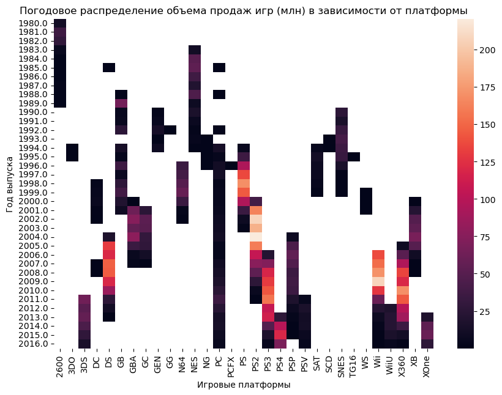

| platform | total_sales |
| --- | --- |
| PS2 | 1255.77 |
| X360 | 971.42 |
| PS3 | 939.65 |
| Wii | 907.51 |
| DS | 806.12 |
| PS | 730.86 |
| GBA | 317.85 |
| PS4 | 314.14 |
| PSP | 294.05 |
| PC | 259.52 |

| platform | total_sales |
| --- | --- |
| PS4 | 314.14 |
| PS3 | 288.79 |
| X360 | 236.54 |
| 3DS | 194.61 |
| XOne | 159.32 |
| WiiU | 82.19 |
| PC | 62.65 |
| PSV | 49.18 |
| Wii | 35.37 |
| DS | 12.55 |
| PSP | 11.19 |

```python
f, ax = plt.subplots(figsize=(10, 7))
platform_pt = df.pivot_table(index=df['year_of_release'].dt.year, columns='platform', values='total_sales', aggfunc='sum')
sns.heatmap(platform_pt)
plt.xlabel('Игровые платформы')
plt.ylabel('Год выпуска')
plt.title('Погодовое распределение объема продаж игр (млн) в зависимости от платформы')
plt.show()
# Также посмотрим наиболее популярные платформы за все время
display(df.pivot_table(index='platform', values='total_sales', aggfunc='sum').sort_values(by='total_sales', ascending=False).head(10))

# Дополнительно оценим популярность платформ за последние 5 лет
display(df[df['year_of_release'] >= pd.Timestamp(ts_input='2012-01-01')].pivot_table(index='platform', values='total_sales', aggfunc='sum').sort_values(by='total_sales', ascending=False))
```

Представленная тепловая карта хорошо показывает эволюцию игровых платформ и наиболее популярные современные платформы. Видно, что жизненный цикл определенной платформы в районе 10-12 лет, пик популярности приходится на 3-5 годы после выпуска платформы, новая версия платформы выходит приблизительно через 6-7 лет. Среди функционирующих игровых платформ наиболее популярными в последние 5 лет являются:

- PS4 (явный лидер по объемам продаж, отмечается рост из года в год (2016г не полный))
- PS3 (однако отмечается спад продаж в последние годы)
- X360 (однако отмечается спад продаж в последние годы)
- 3DS (однако отмечается спад продаж в последние годы)
- XOne (набирает популярность)
- WiiU (отмечается спад продаж)
- PC (стабильные продажи из года в год)
- PSV (стабильно низкие объемы продаж)
- Wii (жизненный цикл платформы близится к концу)

Таким образом мы пришли к выводам, что **актуальный период** для наших дальнейших расчетов является **период с 2012 по 2016гг**, а к наиболее перспективным игровым платформам относятся **PS4** и **XOne**.

### Актуализируем данные

Сохраним в датафрейм `df_actual` данные за последние 5 лет.

```python
df_actual = df[df['year_of_release'] >= pd.Timestamp(ts_input='2012-01-01')]
df_actual.head()
```

|  | name | platform | year_of_release | genre | na_sales | eu_sales | jp_sales | other_sales | critic_score | user_score | rating | total_sales |
| --- | --- | --- | --- | --- | --- | --- | --- | --- | --- | --- | --- | --- |
| 16 | Grand Theft Auto V | PS3 | 2013-01-01 | Action | 7.02 | 9.09 | 0.98 | 3.96 | 97.0 | 8.2 | M | 21.05 |
| 23 | Grand Theft Auto V | X360 | 2013-01-01 | Action | 9.66 | 5.14 | 0.06 | 1.41 | 97.0 | 8.1 | M | 16.27 |
| 31 | Call of Duty: Black Ops 3 | PS4 | 2015-01-01 | Shooter | 6.03 | 5.86 | 0.36 | 2.38 | NaN | NaN | NaN | 14.63 |
| 33 | Pokemon X/Pokemon Y | 3DS | 2013-01-01 | Role-Playing | 5.28 | 4.19 | 4.35 | 0.78 | NaN | NaN | NaN | 14.60 |
| 34 | Call of Duty: Black Ops II | PS3 | 2012-01-01 | Shooter | 4.99 | 5.73 | 0.65 | 2.42 | 83.0 | 5.3 | M | 13.79 |

### Построим график «ящик с усами» по глобальным продажам игр в разбивке по платформам.

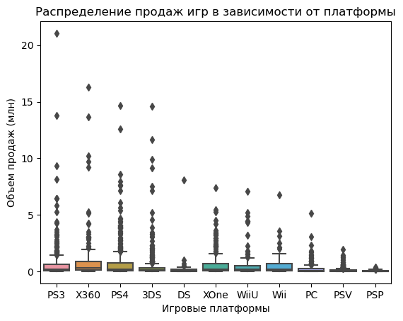

```python
sns.boxplot(data=df_actual, x='platform', y="total_sales")
plt.xlabel('Игровые платформы')
plt.ylabel('Объем продаж (млн)')
plt.title('Распределение продаж игр в зависимости от платформы')
plt.show()
```

Видим, что самая популярная игра за последние 5 лет набрала более 20 млн продаж. В среднем игровые хиты первой пятерки среди игровых платформ набирали 10-15 млн продаж, для замыкающей пятерки - в районе 5-7 млн продаж.  
Ограничим выбросы для более подробной оценки медиан и квартилей.

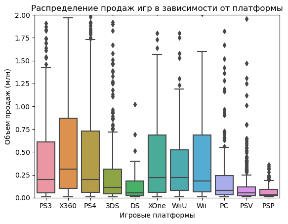

```python
sns.boxplot(data=df_actual, x='platform', y="total_sales")
plt.xlabel('Игровые платформы')
plt.ylabel('Объем продаж (млн)')
plt.ylim(0, 2,5)
plt.title('Распределение продаж игр в зависимости от платформы')
plt.show()
```

Самая высокая медиана продаж у платформы **X360**, расположение квартилей так же показывает, что на данной платформе игры в среднем набирают больше продаж, чем на других платформах. В целом у популярных платформ медиана продаж для отдельной игры находится в районе 220-230 тыс. копий, верхний квартиль в районе 600-700 тыс.

### Оценим взаимосвязь оценок критиков и пользователей с объемами продаж на разных платформах

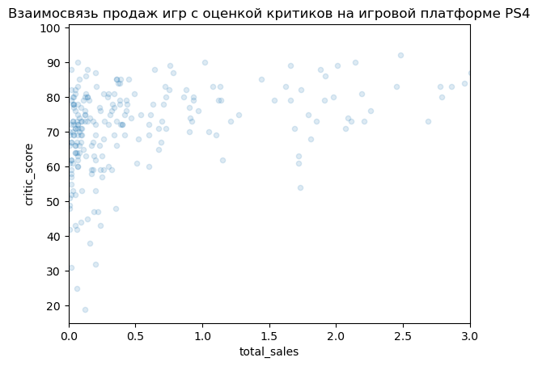

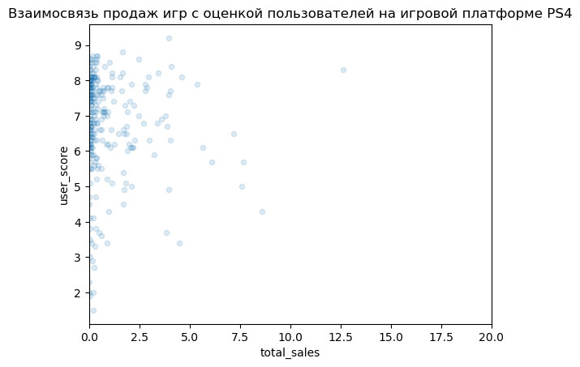

```
Коэффициент корреляции Пирсона между оценкой критиков и объемом продаж игр
на платформe PS4 равен: 0.41
Коэффициент корреляции Пирсона между оценкой пользователей и объемом продаж игр
на платформt PS4 равен: -0.03
```

```python
# Для начала оценим самую перспективную платформу PS4
df_actual[df_actual['platform'] == 'PS4'].plot(x='total_sales',
                                               y='critic_score',
                                               kind='scatter',
                                               title=('Взаимосвязь продаж игр с оценкой критиков на игровой платформе PS4'),
                                               alpha=0.15,
                                               xlim=(0, 3))
plt.show()
df_actual[df_actual['platform'] == 'PS4'].plot(x='total_sales',
                                               y='user_score',
                                               kind='scatter',
                                               title=('Взаимосвязь продаж игр с оценкой пользователей на игровой платформе PS4'),
                                               alpha=0.15,
                                               xlim=(0, 20))
plt.show()
print('''Коэффициент корреляции Пирсона между оценкой критиков и объемом продаж игр
на платформe PS4 равен:''', df_actual[df_actual['platform'] == 'PS4']['total_sales'].corr(df_actual[df_actual['platform'] == 'PS4']['critic_score']).round(2))
print('''Коэффициент корреляции Пирсона между оценкой пользователей и объемом продаж игр
на платформt PS4 равен:''', df_actual[df_actual['platform'] == 'PS4']['total_sales'].corr(df_actual[df_actual['platform'] == 'PS4']['user_score']).round(2))
```

Мы видим слабую взаимосвязь межу оценками критиков, пользователей и показателем объема продаж игр на данной платформе. При этом можно отметить, что чем больше продаж у игр, тем меньше встречается игр с низкой оценкой критиков, вероятно здесь нелинейная корреляция.  
Аналогично оценим оставшиеся платформы.

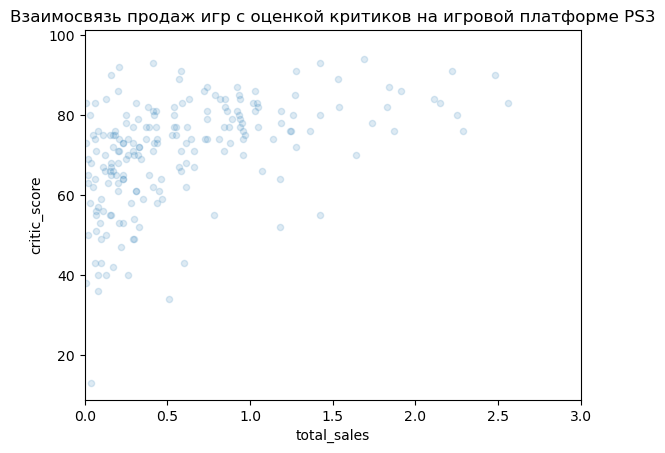

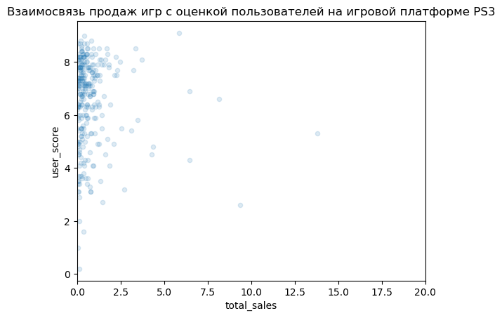

```
Коэффициент корреляции Пирсона между оценкой критиков и объемом продаж игр
на платформe PS3 равен: 0.33
Коэффициент корреляции Пирсона между оценкой пользователей и объемом продаж игр
на платформt PS3 равен: -0.01
```

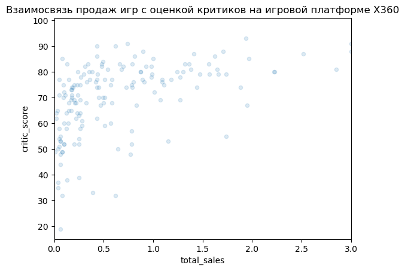

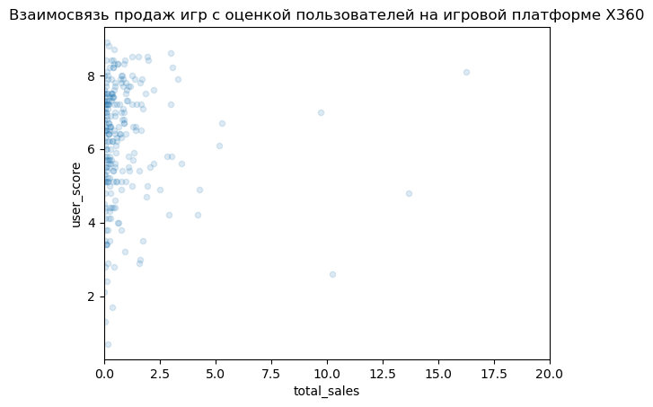

```
Коэффициент корреляции Пирсона между оценкой критиков и объемом продаж игр
на платформe X360 равен: 0.36
Коэффициент корреляции Пирсона между оценкой пользователей и объемом продаж игр
на платформt X360 равен: 0.01
```

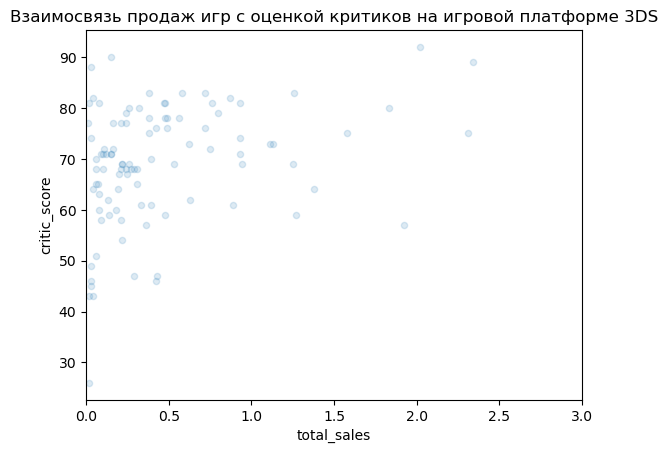

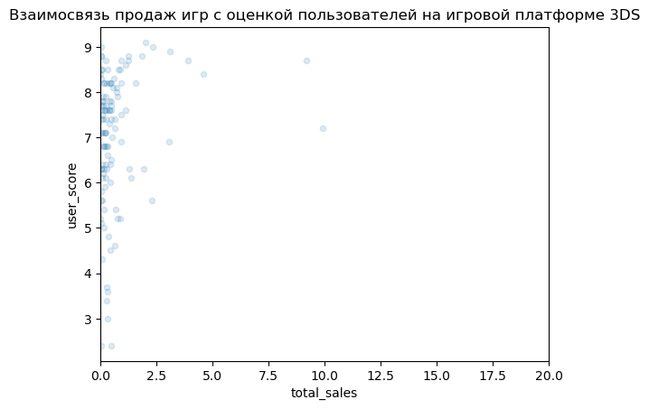

```
Коэффициент корреляции Пирсона между оценкой критиков и объемом продаж игр
на платформe 3DS равен: 0.32
Коэффициент корреляции Пирсона между оценкой пользователей и объемом продаж игр
на платформt 3DS равен: 0.2
```

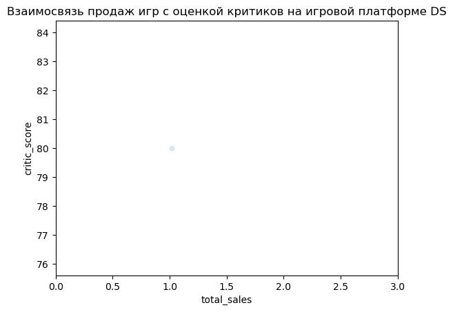

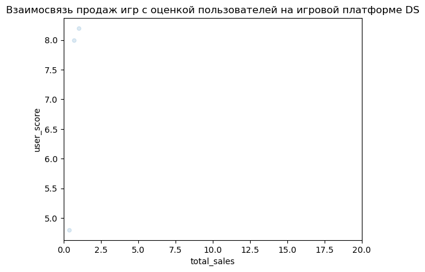

```
Коэффициент корреляции Пирсона между оценкой критиков и объемом продаж игр
на платформe DS равен: nan
Коэффициент корреляции Пирсона между оценкой пользователей и объемом продаж игр
на платформt DS равен: 0.88
```

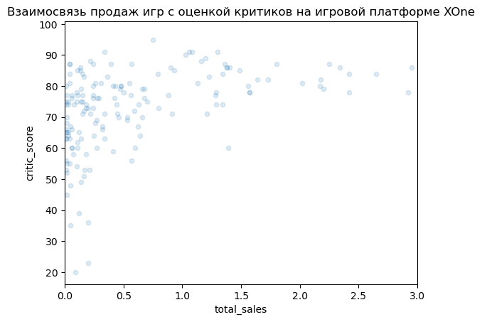

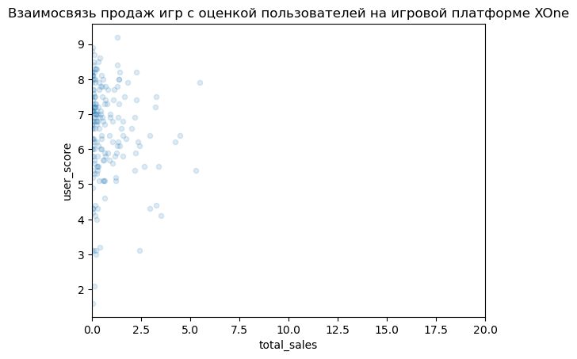

```
Коэффициент корреляции Пирсона между оценкой критиков и объемом продаж игр
на платформe XOne равен: 0.42
Коэффициент корреляции Пирсона между оценкой пользователей и объемом продаж игр
на платформt XOne равен: -0.07
```

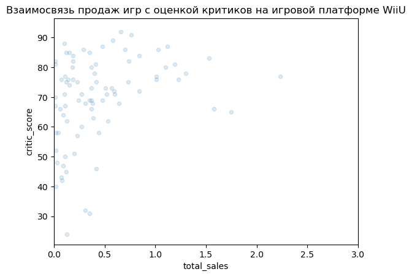

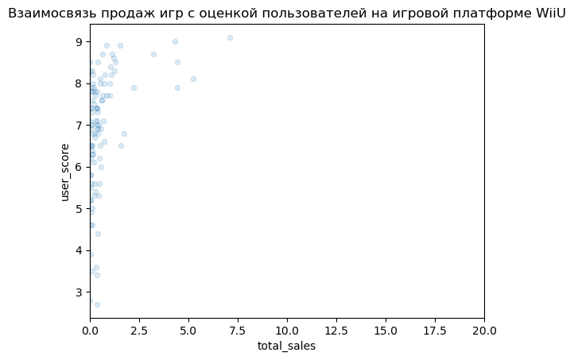

```
Коэффициент корреляции Пирсона между оценкой критиков и объемом продаж игр
на платформe WiiU равен: 0.35
Коэффициент корреляции Пирсона между оценкой пользователей и объемом продаж игр
на платформt WiiU равен: 0.4
```

[8 more figures not shown]

```
Коэффициент корреляции Пирсона между оценкой критиков и объемом продаж игр
на платформe PSP равен: nan
Коэффициент корреляции Пирсона между оценкой пользователей и объемом продаж игр
на платформt PSP равен: -0.8
```

```python
for i in df_actual.loc[df_actual['platform'] != 'PS4', 'platform'].unique():
    df_actual[df_actual['platform'] == i].plot(x='total_sales',
                                                   y='critic_score',
                                                   kind='scatter',
                                                   title=('Взаимосвязь продаж игр с оценкой критиков на игровой платформе ' + i),
                                                   alpha=0.15,
                                                   xlim=(0, 3))
    plt.show()
    df_actual[df_actual['platform'] == i].plot(x='total_sales',
                                                   y='user_score',
                                                   kind='scatter',
                                                   title=('Взаимосвязь продаж игр с оценкой пользователей на игровой платформе ' + i),
                                                   alpha=0.15,
                                                   xlim=(0, 20))
    plt.show()
    print(f'''Коэффициент корреляции Пирсона между оценкой критиков и объемом продаж игр
на платформe {i} равен:''', df_actual[df_actual['platform'] == i]['total_sales'].corr(df_actual[df_actual['platform'] == i]['critic_score']).round(2))
    print(f'''Коэффициент корреляции Пирсона между оценкой пользователей и объемом продаж игр
на платформt {i} равен:''', df_actual[df_actual['platform'] == i]['total_sales'].corr(df_actual[df_actual['platform'] == i]['user_score']).round(2))
```

Для остальных платформ выявлены схожие результаты. Четкой линейной взаимосвязи между объемом продаж и оценками критиков и пользователей нет!

### Оценим распреденение объема продаж игр в зависимости от жанра

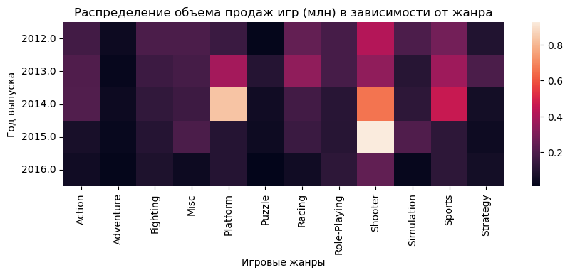

```
              total_sales
genre
Shooter             0.440
Sports              0.240
Platform            0.210
Role-Playing        0.140
Racing              0.140
Fighting            0.130
Action              0.120
Misc                0.120
Simulation          0.120
Strategy            0.080
Puzzle              0.045
Adventure           0.030
```

```python
f, ax = plt.subplots(figsize=(10, 3))
sns.heatmap(df_actual.pivot_table(index=df['year_of_release'].dt.year, columns='genre', values='total_sales', aggfunc='median'))
plt.xlabel('Игровые жанры')
plt.ylabel('Год выпуска')
plt.title('Распределение объема продаж игр (млн) в зависимости от жанра')
plt.show()
print(df_actual.pivot_table(index='genre', values='total_sales', aggfunc='median').sort_values(by='total_sales', ascending=False))
```

## Портрет среднестатистического пользователя в зависимости от региона продаж

### Оценим ТОП-5 игровых платформ среди пользователей различных регионов

```python
#создадим словарь с регионами продаж
region_dict = {'na':'Северная Америка', 'eu':'Европа', 'jp':'Япония'}

#Создадим функциюдля построения свойдной таблицы топ-5 чего-либо по регионам
def top5_table(smth):
    top5_smth_by_region = pd.DataFrame()
    for region in region_dict:
        top5_smth_by_region = top5_smth_by_region.merge(df_actual.pivot_table(index=smth,
                                                                                      values=region + '_sales',
                                                                                      aggfunc='sum')
                                                                .sort_values(by=region + '_sales',
                                                                             ascending=False)
                                                                .head()
                                                                .reset_index()
                                                                .rename(columns={smth:region_dict[region]}),
                                                                        left_index=True, right_index=True, how='right')
    return top5_smth_by_region
```

```python
top5_table('platform')
```

|  | Северная Америка | na_sales | Европа | eu_sales | Япония | jp_sales |
| --- | --- | --- | --- | --- | --- | --- |
| 0 | X360 | 140.05 | PS4 | 141.09 | 3DS | 87.79 |
| 1 | PS4 | 108.74 | PS3 | 106.86 | PS3 | 35.29 |
| 2 | PS3 | 103.38 | X360 | 74.52 | PSV | 21.04 |
| 3 | XOne | 93.12 | XOne | 51.59 | PS4 | 15.96 |
| 4 | 3DS | 55.31 | 3DS | 42.64 | WiiU | 13.01 |

```python
# Подкрепим таблицу диаграммами
# Напишем функцию для выводы диаграмм
def top5_diagramm(smth, title):
    for region in region_dict:
        plt.figure(0)
        (df_actual.pivot_table(index=smth, values=region + '_sales', aggfunc='sum')
         .sort_values(by=region + '_sales', ascending=False).head()
         .plot(subplots=True,
               kind='pie',
               figsize=(6, 6),
               ylabel='',
               title=title + region_dict[region]));
    return
```

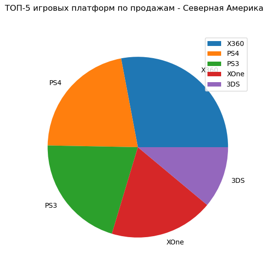

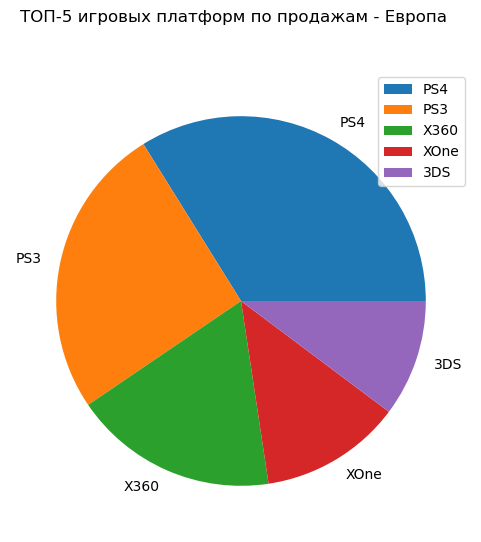

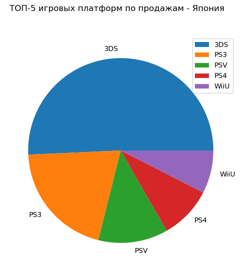

```python
top5_diagramm('platform', 'ТОП-5 игровых платформ по продажам - ')
```

Видно, что предпочтения в выборе игровой платформы у пользователей различных регионов значительно различаются. Пользователи из Северной Америки предпочитают **X360**, из Европы - **РS4**, из Японии - **3DS**. При этом ТОП-5 игровых платформ в Америке и Европе одинаковы, а в Японии вместо **X360** и **XOne** (разработанных в США) присутсвуют только местные платформы, подавляющее большинство приходится на **3DS**.

### Оценим ТОП-5 игровых жанров среди пользователей различных регионов

```python
top5_table('genre')
```

|  | Северная Америка | na_sales | Европа | eu_sales | Япония | jp_sales |
| --- | --- | --- | --- | --- | --- | --- |
| 0 | Action | 177.84 | Action | 159.34 | Role-Playing | 65.44 |
| 1 | Shooter | 144.77 | Shooter | 113.47 | Action | 52.80 |
| 2 | Sports | 81.53 | Sports | 69.09 | Misc | 12.86 |
| 3 | Role-Playing | 64.00 | Role-Playing | 48.53 | Simulation | 10.41 |
| 4 | Misc | 38.19 | Racing | 27.29 | Fighting | 9.44 |

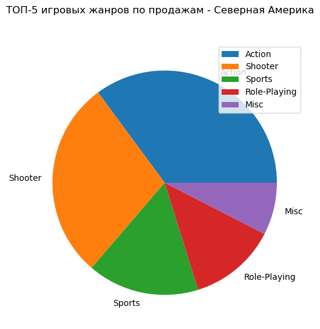

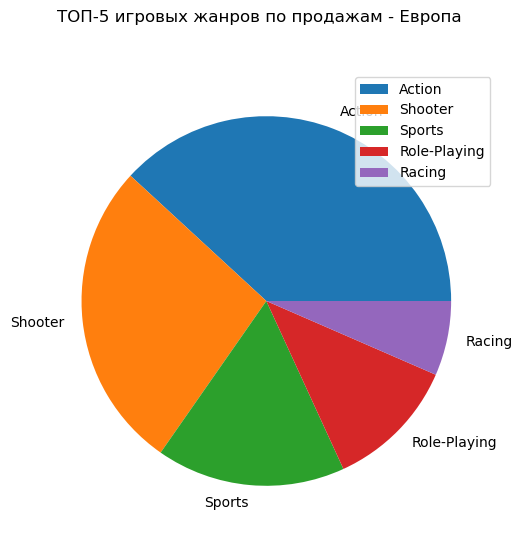

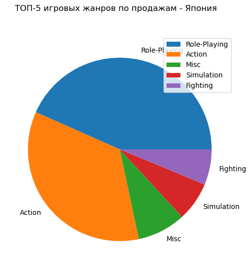

```python
top5_diagramm('genre', 'ТОП-5 игровых жанров по продажам - ')
```

С игровыми жанрами также отмечается схожие предпочтения вреди пользователей Северной Америки и Европы. В обоих регионах превалирующее большинство пользователей предпочитают жанры **Action** и **Shooter**. В Японии жанр **Action** также пользуется большой популярностью, однако первое место занимает жанр **Role-Playing**.

### Оценим продажи игр по регионам в зависимости от рейтинга

```python
# Заменим пропуски в rating на значение-заглушку 'unknown'
df_actual['rating'].fillna(value='unknown', inplace=True)

top5_table('rating')
```

|  | Северная Америка | na_sales | Европа | eu_sales | Япония | jp_sales |
| --- | --- | --- | --- | --- | --- | --- |
| 0 | M | 231.57 | M | 193.96 | unknown | 108.84 |
| 1 | E | 114.37 | E | 113.03 | E | 28.33 |
| 2 | unknown | 103.31 | unknown | 91.50 | T | 26.02 |
| 3 | E10+ | 75.70 | E10+ | 55.37 | M | 21.20 |
| 4 | T | 66.02 | T | 52.96 | E10+ | 8.19 |

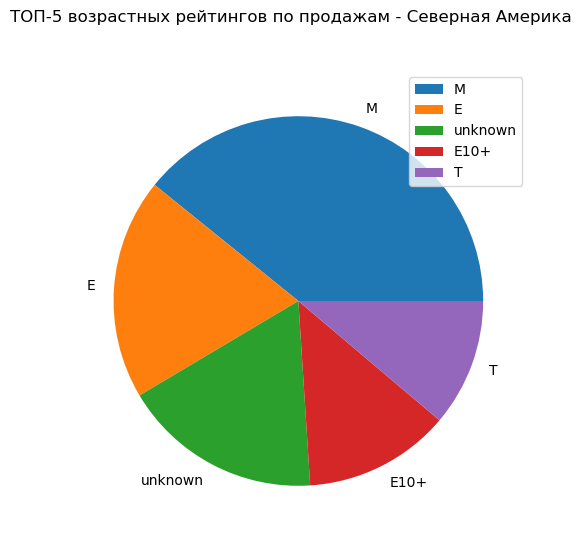

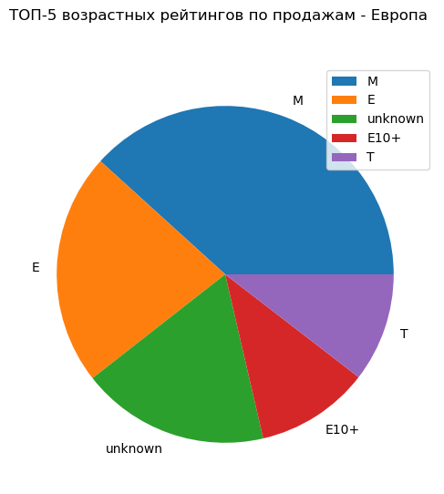

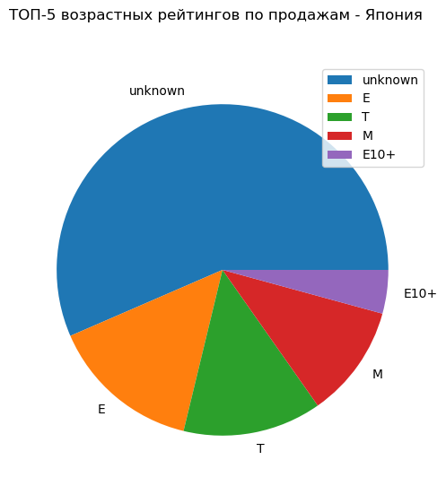

```python
# Подкрепим таблицу диаграммами
top5_diagramm('rating', 'ТОП-5 возрастных рейтингов по продажам - ')
```

Около 1/3 объема продаж в Северной Америке и Европе приходится на игры с рейтингом **М** (для лиц старше 17 лет), что говорит о пристрастии данных пользователей к более агрессивным играм. Около четверти приходится на игры с рейтингом **Е** (для всех), чуть меньше занимают игры, не имеющие рейтинга ESRB и оставшуюся часть примерно поровно делят игры с рейтингом **T** (для лиц старше 17 лет) и **Е10+** (для лиц старше 10 лет). В Японии более половины игр не имеют рейтинга ESRB, примерно 1/4 объема продаж приходится на игры с рейтингом **Т** и **Е**, оставшаяся часть приходится на рейтинги **М** и **Е10+**.

Данные результаты показывают, что производителю игр для рынка Северной Америки и Европы важно получить рейтинг ESRB, так как среди пользователей пользуется большей популярность игры с установленным рейтингом. Обратная ситуация в Японии, где наличие рейтинга ESRB особо не влияет на выбор покупателя (большая часть проданных игр не имеет рейтинга ESRB), поэтому производители могут не получать рейтинг для своей продукции.

## Проверка гипотез

### Средние пользовательские рейтинги платформ Xbox One и PC одинаковые?

Предположим, что средние пользовательские рейтинги платформ **Xbox One** и **PC** равны.  
Нулевая гипотеза: средняя оценка пользователей **Xbox One** = средняя оценка пользователей **PC**  
Альтернативная гипотеза: средняя оценка пользователей **Xbox One** ≠ средняя оценка пользователей **PC**  
Уровень значимости = 0,05

В качестве статистического метода в данном случае уместно использовать t-test, так как наши данные количественные, величина выборки более 30 наблюдений (распределение Стьюдента близится к нормальному), генеральные сосокупности независимые. Равенство дисперсий нам неизвестно, поэтому отразим это при проведении t-теста (equal_var=False).

```python
alpha = .05

result = st.ttest_ind((df_actual.loc[df_actual['platform'] == 'XOne']['user_score'].dropna()),
                      (df_actual.loc[df_actual['platform'] == 'PC']['user_score'].dropna()),
                      equal_var=False)
if result[1] < alpha:
    print(f'Отвергаем нулевую гипотезу, значение p-value = {result[1]:.3f}')
else:
    print(f'Нулевую гипотезу отвергнуть не удалось, значение p-value = {result[1]:.3f}')

    # Дополнительно оценим описательные статистики для указанных данных
print('Среднее, медиана и квартили для Xbox One')
print(df_actual.loc[df_actual['platform'] == 'XOne']['user_score'].describe())
print('Среднее, медиана и квартили для PC')
print(df_actual.loc[df_actual['platform'] == 'PC']['user_score'].describe())
```

```
Нулевую гипотезу отвергнуть не удалось, значение p-value = 0.549
Среднее, медиана и квартили для Xbox One
count    182.000000
mean       6.521429
std        1.380941
min        1.600000
25%        5.800000
50%        6.800000
75%        7.500000
max        9.200000
Name: user_score, dtype: float64
Среднее, медиана и квартили для PC
count    206.000000
mean       6.428641
std        1.664465
min        1.400000
25%        5.500000
50%        6.800000
75%        7.700000
max        9.300000
Name: user_score, dtype: float64
```

Мы проверили гипотезу при помощи двустороннего t-теста. По итогам проверки **на основе имеющихся данных** мы пришли к выводу, что средние оценки пользователей платформ **Xbox One** и **PC** **равны**, значение p-value = 0,55. Об этом также могут свидетельствовать схожие значения средних и медиан в данных группах.

### Средние пользовательские рейтинги жанров Action и Sports разные?

Предположим, что средние пользовательские рейтинги жанров **Action** и **Sports** разные. Нулевая гипотеза: средняя оценка пользователей жанра **Action** = средняя оценка пользователей жанра **Sports** Альтернативная гипотеза: средняя оценка пользователей жанра **Action** ≠ средняя оценка пользователей жанра **Sports**  
Уровень значимости = 0,05

```python
alpha = .05

result = st.ttest_ind((df_actual.loc[df_actual['genre'] == 'Action']['user_score'].dropna()),
                      (df_actual.loc[df_actual['genre'] == 'Sports']['user_score'].dropna()),
                      equal_var=False)
if result[1] < alpha:
    print(f'Отвергаем нулевую гипотезу, значение p-value = {result[1]:.3f}')
else:
    print(f'Нулевую гипотезу отвергнуть не удалось, значение p-value = {result[1]:.3f}')

# Дополнительно оценим описательные статистики для указанных данных
print('Среднее, медиана и квартили для жанра Action')
print(df_actual.loc[df_actual['genre'] == 'Action']['user_score'].describe())
print('Среднее, медиана и квартили для жанра Sports')
print(df_actual.loc[df_actual['genre'] == 'Sports']['user_score'].describe())
```

```
Отвергаем нулевую гипотезу, значение p-value = 0.000
Среднее, медиана и квартили для жанра Action
count    523.000000
mean       6.825048
std        1.374440
min        1.600000
25%        6.250000
50%        7.100000
75%        7.800000
max        9.100000
Name: user_score, dtype: float64
Среднее, медиана и квартили для жанра Sports
count    195.000000
mean       5.455897
std        1.738646
min        0.200000
25%        4.300000
50%        5.700000
75%        6.800000
max        8.800000
Name: user_score, dtype: float64
```

Полученные результаты позволяют нам отвергнуть нулевую гипотезу. Следовательно наше предположение о том, что средние пользовательские рейтинги жанров **Action** и **Sports** разные, оказалось верным! Значение p-value менее 0,001 и стремится к нулю.

# Итоги проведенного исследования

В ходе исследования нам было необходимо выявить показатели и закономерности, определяющие успешность игр, для планирования рекламной кампании в интернет-магазине 'Стримчик'.

В ходе исследования мы использовали открытые данные по продажам игр за разные года вплоть до 2016г. Нам пришлось выполнить предобработку данных так как данные были неподготовлены для анализа:

- заменили названия столбцов на общепринятый **`змеиный_регистр`**;
- преобразовали данные в нужные типы (**year_of_release** в тип `datetime`, **user_score** в тип `float64`, обработать пропуски при необходимости);
- заполнили пропуски (В столбце **user_score** заменили значения **tbd** на **NaN**, чтобы можно было вести работу с цифрами и не потерять около половины данных. Данное значение **tbd** вероятно возникло из-за ошибок системы сбора статистики. В столбцах с оценками пропуски оставили, так-так оценки игры среди пользователей предугадать сложно, в разных версиях игр могут быть 'взлеты' и 'падения'.);
- посчитали общий объем продаж по каждой позиции.

Далее для возможности запуска таргетированной рекламы мы оценили портрет средненго пользователя каждого региона. Определили для пользователей каждого региона (NA (Северная Америка), EU (Европа), JP (Япония)):

- ТОП-5 популярных игровых платформ (Видно, что предпочтения в выборе игровой платформы у пользователей различных регионов значительно различаются. Пользователи из Северной Америки предпочитают **X360**, из Европы - **РS4**, из Японии - **3DS**. При этом ТОП-5 игровых платформ в Америке и Европе одинаковы, а в Японии вместо **X360** и **XOne** (разработанных в США) присутсвуют только местные платформы, подавляющее большинство приходится на **3DS**.);
- ТОП-5 популярных жанров (С игровыми жанрами также отмечается схожие предпочтения вреди пользователей Северной Америки и Европы. В обоих регионах превалирующее большинство пользователей предпочитают жанры **Action** и **Shooter**. В Японии жанр **Action** также пользуется большой популярностью, однако первое место занимает жанр **Role-Playing**.);
- влияние рейтинга ESRB на продажи в отдельном регионе (Около 1/3 объема продаж в Северной Америке и Европе приходится на игры с рейтингом **М** (для лиц старше 17 лет), что говорит о пристрастии данных пользователей к более агрессивным играм. Около четверти приходится на игры с рейтингом **Е** (для всех), чуть меньше занимают игры, не имеющие рейтинга ESRB и оставшуюся часть примерно поровно делят игры с рейтингом **T** (для лиц старше 17 лет) и **Е10+** (для лиц старше 10 лет). В Японии более половины игр не имеют рейтинга ESRB, примерно 1/4 объема продаж приходится на игры с рейтингом **Т** и **Е**, оставшаяся часть приходится на рейтинги **М** и **Е10+**. Данные результаты показывают, что производителю игр для рынка Северной Америки и Европы важно получить рейтинг ESRB, так как среди пользователей пользуется большей популярность игры с установленным рейтингом. Обратная ситуация в Японии, где наличие рейтинга ESRB особо не влияет на выбор покупателя (большая часть проданных игр не имеет рейтинга ESRB), поэтому производители могут не получать рейтинг для своей продукции.).

На следующем этапе проверили выдвинутые нами гипотезы с применением методов сатитстической обработки данных:

- Гипотеза 1. Средние пользовательские рейтинги платформ **Xbox One** и **PC** равны.  
  Нулевая гипотеза: средняя оценка пользователей **Xbox One** = средняя оценка пользователей **PC**  
  Альтернативная гипотеза: средняя оценка пользователей **Xbox One** ≠ средняя оценка пользователей **PC**  
  Уровень значимости = 0,05 Мы проверили гипотезу при помощи двустороннего t-теста. По итогам проверки **на основе имеющихся данных** мы пришли к выводу, что средние оценки пользователей платформ **Xbox One** и **PC** **равны**, значение p-value = 0,55. Об этом также могут свидетельствовать схожие значения средних и медиан в данных группах.
- Гипотеза 2. Средние пользовательские рейтинги жанров `Action` и `Sports` разные.  
  Нулевая гипотеза: средняя оценка пользователей жанра `Action` = средняя оценка пользователей жанра `Sports`  
  Альтернативная гипотеза: средняя оценка пользователей жанра `Action` ≠ средняя оценка пользователей жанра `Sports`  
  Уровень значимости = 0,05  
  Полученные результаты позволяют нам отвергнуть нулевую гипотезу. Следовательно наше предположение о том, что средние пользовательские рейтинги жанров `Action` и `Sports` разные, оказалось верным! Значение p-value менее 0,001 и стремится к нулю.

**Заключительные выводы:**

- При планировании рекламной кампании необходимо делать акцент на наиболее перспективные игровые платформы **PS4** и **XOne**, среди игровых жанров предпочтение необходимо отдать `Action`, `Shooter`, `Role-Playing`, `Sports`.
- При возвожности запуска таргетированной рекламы необходимо учитывать особенности региона продаж:
  - Северная Америка (NA) - необходимо делать акцент на игровые платформы **X360**, **PS4**, **PS3**, **XOne**, **3DS**, игровые жанры `Action`, `Shooter`, `Sports`, рейтинг ESRB **M** и **E**.
  - Европа (EU) - необходимо делать акцент на игровые платформы **PS4**, **PS3**, **X360**, **XOne**, **3DS**, игровые жанры `Action`, `Shooter`, `Sports`, рейтинг ESRB **M** и **E**.
  - Япония (JP) - необходимо делать акцент на игровые платформы **3DS**, **PS3**, **PSV**, **PS4**, **WiiU**, игровые жанры `Role-Playing`, `Action`, `Misc`, рейтинг ESRB не особо важен, а среди игр с рейтингом превалируют **T** и **E**.